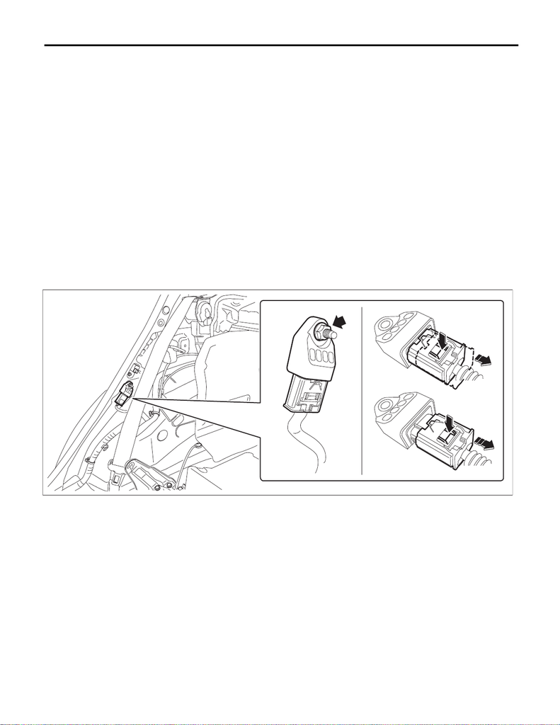

AB-56

Curtain Airbag Sensor

AIRBAG SYSTEM

13.Curtain Airbag Sensor

A: REMOVAL

CAUTION:

• Airbag system satellite safing sensor is located in the lower of the rear seat cushion center. Before

removing the rear seat, refer to “CAUTION” of “General Description” in “AIRBAG SYSTEM” section.

<Ref. to AB-9, CAUTION, General Description.>

• The airbag system is fitted with a backup power supply. After disconnecting the battery ground ca-

ble, the airbag may operate if you do not wait for 60 seconds before starting the service of airbag sys-

tem.

1) Turn the ignition switch to OFF.

2) Disconnect the ground cable from battery and wait for at least 60 seconds before starting work. <Ref. to

NT-5, BATTERY, NOTE, Note.>

NOTE:

For models other than STI model, disconnect the ground terminal from battery sensor.

3) Remove the rear seat cushion assembly. <Ref. to SE-29, REMOVAL, Rear Seat.>

4) Remove the cover side sill - rear INN and the trim panel - rear pillar LWR. <Ref. to EI-89, REMOVAL, Rear

Quarter Trim.>

AB-02908

(3)

(4)

(2)

(1)

[figure not shown]

AB-57

Curtain Airbag Sensor

AIRBAG SYSTEM

B: INSTALLATION

1) Before installation, inspect the following items and replace any faulty part with a new one.

• Curtain airbag sensor or connector is damaged.

• Curtain airbag module has been activated.

CAUTION:

• Do not reuse the bolt and nut.

Always replace with the specified new bolts and nuts.

• When installing the sensor, insert the set pin on the backside of the sensor into the hole on the

body side securely.

Tightening torque:

7.5 N·m (0.8 kgf-m, 5.5 ft-lb)

3) Install the cover side sill - rear INN and the trim panel - rear pillar LWR.

4) Install the rear seat cushion assembly.

5) Connect the battery ground terminal. <Ref. to NT-5, BATTERY, NOTE, Note.>

NOTE:

For models other than STI model, connect the ground terminal to battery sensor.